# **Netflix Data Analysis**

The Netflix dataset consists of data collected by Netflix on the movies and TV shows that they offer. This data includes description, year of release, and other metadata about the content. Analysis of this dataset can be used to understand viewer preferences, analysis of the Netflix dataset might include:

- What type of shows that Netflix is focusing on?
- What type of content that Netflix focus more?
- The trend of the shows on Netflix by years
- Top 5 directors and actors that appeared most on Netflix?
- Most produced genres on Netflix
- Sentiment content analysis on Netflix shows over the years

### Installing and importing necessary packages for analysis

```python
pip install textblob
```

```python
pip install plotly==5.11.0
```

```python
import numpy as np # linear algebra
import pandas as pd # for data preparation
import matplotlib.pyplot as plt # for data visualization
%matplotlib inline
from textblob import TextBlob # for sentiment analysis
```

```python
pd.options.mode.chained_assignment = None
```

### Inputing the CSV file and initial checking of the data

```python
df = pd.read_csv('netflix_titles.csv')
```

```python
df.shape
```

```
(8807, 12)
```

```python
df.dtypes
```

```
show_id         object
type            object
title           object
director        object
cast            object
country         object
date_added      object
release_year     int64
rating          object
duration        object
listed_in       object
description     object
dtype: object
```

```python
df.columns
```

```
Index(['show_id', 'type', 'title', 'director', 'cast', 'country', 'date_added',
       'release_year', 'rating', 'duration', 'listed_in', 'description'],
      dtype='object')
```

```python
df["rating"].unique()
```

```
array(['PG-13', 'TV-MA', 'PG', 'TV-14', 'TV-PG', 'TV-Y', 'TV-Y7', 'R',
       'TV-G', 'G', 'NC-17', '74 min', '84 min', '66 min', 'NR', nan,
       'TV-Y7-FV', 'UR'], dtype=object)
```

```python
rating_list = ['74 min', '84 min', '66 min']
```

['74 min', '84 min', '66 min'] should not be in the rating, move them to their respective column

```python
wrong_rating_list = df[df.rating.isin(rating_list)]
```

```python
wrong_rating_list
```

|  | show_id | type | title | director | cast | country | date_added | release_year | rating | duration | listed_in | description |
| --- | --- | --- | --- | --- | --- | --- | --- | --- | --- | --- | --- | --- |
| 5541 | s5542 | Movie | Louis C.K. 2017 | Louis C.K. | Louis C.K. | United States | April 4, 2017 | 2017 | 74 min | NaN | Movies | Louis C.K. muses on religion, eternal love, gi... |
| 5794 | s5795 | Movie | Louis C.K.: Hilarious | Louis C.K. | Louis C.K. | United States | September 16, 2016 | 2010 | 84 min | NaN | Movies | Emmy-winning comedy writer Louis C.K. brings h... |
| 5813 | s5814 | Movie | Louis C.K.: Live at the Comedy Store | Louis C.K. | Louis C.K. | United States | August 15, 2016 | 2015 | 66 min | NaN | Movies | The comic puts his trademark hilarious/thought... |

```python
df.loc[df['show_id'] == 's5542', 'duration'] = '74 min'
df.loc[df['show_id'] == 's5795', 'duration'] = '84 min'
df.loc[df['show_id'] == 's5814', 'duration'] = '66 min'
```

```python
wrong_rating_list = df[df.rating.isin(rating_list)]
```

```python
## Louis C.K. show rating are TV-MA after researching
df.loc[df['director'] == 'Louis C.K.', 'rating'] = 'TV-MA'
```

```python
df[df['director']=='Louis C.K.']
```

|  | show_id | type | title | director | cast | country | date_added | release_year | rating | duration | listed_in | description |
| --- | --- | --- | --- | --- | --- | --- | --- | --- | --- | --- | --- | --- |
| 5541 | s5542 | Movie | Louis C.K. 2017 | Louis C.K. | Louis C.K. | United States | April 4, 2017 | 2017 | TV-MA | 74 min | Movies | Louis C.K. muses on religion, eternal love, gi... |
| 5794 | s5795 | Movie | Louis C.K.: Hilarious | Louis C.K. | Louis C.K. | United States | September 16, 2016 | 2010 | TV-MA | 84 min | Movies | Emmy-winning comedy writer Louis C.K. brings h... |
| 5813 | s5814 | Movie | Louis C.K.: Live at the Comedy Store | Louis C.K. | Louis C.K. | United States | August 15, 2016 | 2015 | TV-MA | 66 min | Movies | The comic puts his trademark hilarious/thought... |

### Creating the rating distribution table for the pie chart

```python
r_distribution = df['rating'].value_counts().rename_axis('rating').reset_index(name='counts')
r_distribution
```

|  | rating | counts |
| --- | --- | --- |
| 0 | TV-MA | 3210 |
| 1 | TV-14 | 2160 |
| 2 | TV-PG | 863 |
| 3 | R | 799 |
| 4 | PG-13 | 490 |
| 5 | TV-Y7 | 334 |
| 6 | TV-Y | 307 |
| 7 | PG | 287 |
| 8 | TV-G | 220 |
| 9 | NR | 80 |
| 10 | G | 41 |
| 11 | TV-Y7-FV | 6 |
| 12 | UR | 3 |
| 13 | NC-17 | 3 |

```python
## Setting labels and values
p_labels = r_distribution.rating
p_values = r_distribution.counts
```

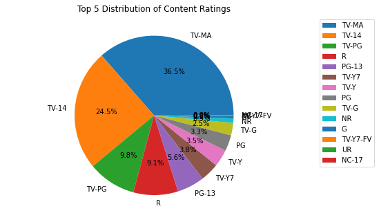

```python
## Visualizing the pie chart
fig = plt.figure()
ax = fig.add_axes([0,0,1,1])
ax.axis('equal')
ax.pie(p_values, labels = p_labels, autopct='%1.1f%%')
plt.title('Top 5 Distribution of Content Ratings')
plt.legend(bbox_to_anchor=(1.25,1))
plt.show()
```

### Content Trend by Year

```python
# Extracting the movie and tv show, grouping them together by the year and prepping for the chart
df1 = df[['type','release_year']]
df1 = df1.rename(columns={"release_year": "Year of Release"})
df2 = df1.groupby(['Year of Release', 'type']).size().reset_index(name="Content Counts")
df2 = df2[df2['Year of Release'] >= 2010]
```

```python
df2
```

|  | Year of Release | type | Content Counts |
| --- | --- | --- | --- |
| 95 | 2010 | Movie | 154 |
| 96 | 2010 | TV Show | 40 |
| 97 | 2011 | Movie | 145 |
| 98 | 2011 | TV Show | 40 |
| 99 | 2012 | Movie | 173 |
| 100 | 2012 | TV Show | 64 |
| 101 | 2013 | Movie | 225 |
| 102 | 2013 | TV Show | 63 |
| 103 | 2014 | Movie | 264 |
| 104 | 2014 | TV Show | 88 |
| 105 | 2015 | Movie | 398 |
| 106 | 2015 | TV Show | 162 |
| 107 | 2016 | Movie | 658 |
| 108 | 2016 | TV Show | 244 |
| 109 | 2017 | Movie | 767 |
| 110 | 2017 | TV Show | 265 |
| 111 | 2018 | Movie | 767 |
| 112 | 2018 | TV Show | 380 |
| 113 | 2019 | Movie | 633 |
| 114 | 2019 | TV Show | 397 |
| 115 | 2020 | Movie | 517 |
| 116 | 2020 | TV Show | 436 |
| 117 | 2021 | Movie | 277 |
| 118 | 2021 | TV Show | 315 |

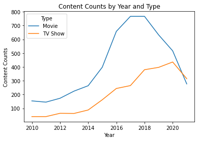

```python
#reshaping the dataframe
df3 = df2.pivot(index='Year of Release', columns='type', values='Content Counts')

# Create the plot
df3.plot()

# Customize the plot
plt.xlabel('Year')
plt.ylabel('Content Counts')
plt.title('Content Counts by Year and Type')
plt.legend(title='Type')
plt.show()
```

The line graph shows that Netflix's production is focused more on movies. However, there has been a decline in production decline around 2019, which can be due to the pandemic. Around 2021, movie production seems to decline more than TV shows for the first time since 2010.

### Top 5 directors and actors that appeared most on Netflix

```python
df.head(1)
```

|  | show_id | type | title | director | cast | country | date_added | release_year | rating | duration | listed_in | description |
| --- | --- | --- | --- | --- | --- | --- | --- | --- | --- | --- | --- | --- |
| 0 | s1 | Movie | Dick Johnson Is Dead | Kirsten Johnson | NaN | United States | September 25, 2021 | 2020 | PG-13 | 90 min | Documentaries | As her father nears the end of his life, filmm... |

### Top 5 directors

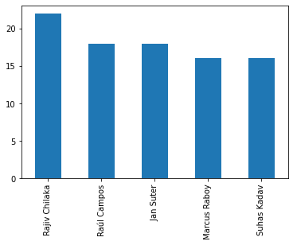

```python
# drop rows with NaN values in the director column
clean_data = df.dropna(subset=['director'])

# spliting the name
clean_data.loc[:, 'director_split'] = clean_data['director'].apply(lambda x: x.split(','))

# use the explode function to create a new row for each split name
clean_data = clean_data.explode('director_split')

# count the frequency of each name and sort in descending order
name_counts = clean_data['director_split'].value_counts().sort_values(ascending=False)

# get the top 5 names
top_names = name_counts.head(5)

# plot the top names using a bar chart
top_names.plot(kind='bar')
plt.show()
```

### Top 5 actors

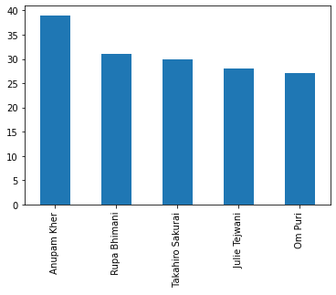

```python
# drop rows with NaN values in the cast column
clean_data_cast = df.dropna(subset=['cast'])

# split the names
clean_data_cast['cast_split'] = clean_data_cast['cast'].apply(lambda x: x.split(','))

# use the explode function to create a new row for each split name
clean_data_cast = clean_data_cast.explode('cast_split')

# count the frequency of each name and sort in descending order
name_counts = clean_data_cast['cast_split'].value_counts().sort_values(ascending=False)

# get the top 5 names
top_names = name_counts.head(5)

# plot the top names using a bar chart
top_names.plot(kind='bar')
plt.show()
```

### Sentimental Contents Analysis

This analysis is done to find out what type of content Netflix is producing over the years.

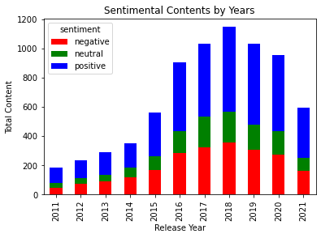

```python
# select only the rows with a year greater than 2010
df = df[df['release_year'] > 2010]

# create an empty list to store the sentiments
sentiments = []

# loop through the description column and analyze the sentiment of each description
for description in df['description']:
    sentiment = TextBlob(description).sentiment.polarity
    # assign a label based on the polarity range
    if sentiment > 0:
        label = 'positive'
    elif sentiment < 0:
        label = 'negative'
    else:
        label = 'neutral'
    sentiments.append(label)

# add the sentiments to the DataFrame
df['sentiment'] = sentiments

# group the data by year and compute the count of each sentiment for each year
yearly_sentiment = df.groupby('release_year')['sentiment'].value_counts()

# pivot the data from the sentiment column into columns
yearly_sentiment = yearly_sentiment.unstack()

# plot the yearly sentiment
plot = yearly_sentiment.plot(kind='bar', stacked=True, color=['red', 'green', 'blue'], legend=True)

plt.title('Sentimental Contents by Years')
plt.xlabel('Release Year')
plt.ylabel('Total Content')

plt.show()
```

From the stacked bar chart, we can see that Netflix focuses more on overall positive content on their platform.

### Top genres on Netflix

```python
# Filter the dataframe to only include rows where the year is >= 2010
df_filtered = df[df['release_year'] >= 2010]

# Split the genres column into separate rows
df_splitted = df_filtered.assign(listed_in=df_filtered.listed_in.str.split(',')).explode('listed_in')

# Drop rows with null values in the genres column
df_cleaned = df_splitted.dropna(subset=['listed_in'])

# Group the data by year
df_grouped = df_cleaned.groupby('release_year')

# Count the frequency of each genre within each year group
genre_counts = df_grouped['listed_in'].value_counts().unstack()
```

```python
genre_counts
```

| listed_in release_year | Anime Features | Children & Family Movies | Classic & Cult TV | Comedies | Crime TV Shows | Cult Movies | Documentaries | Docuseries | Dramas | Faith & Spirituality | ... | Romantic TV Shows | Sci-Fi & Fantasy | Stand-Up Comedy | Stand-Up Comedy & Talk Shows | TV Action & Adventure | TV Comedies | TV Dramas | TV Horror | TV Shows | Thrillers |
| --- | --- | --- | --- | --- | --- | --- | --- | --- | --- | --- | --- | --- | --- | --- | --- | --- | --- | --- | --- | --- | --- |
| 2011 | 6.0 | NaN | NaN | 42.0 | NaN | NaN | NaN | 3.0 | 84.0 | 3.0 | ... | NaN | NaN | 5.0 | NaN | NaN | NaN | NaN | NaN | NaN | 1.0 |
| 2012 | 6.0 | NaN | NaN | 32.0 | 3.0 | 6.0 | NaN | NaN | 66.0 | 3.0 | ... | NaN | NaN | 12.0 | NaN | NaN | NaN | NaN | NaN | NaN | NaN |
| 2013 | 9.0 | NaN | NaN | 42.0 | NaN | 3.0 | 3.0 | 2.0 | 66.0 | 5.0 | ... | NaN | NaN | 8.0 | NaN | NaN | NaN | NaN | NaN | NaN | 1.0 |
| 2014 | 6.0 | NaN | NaN | 42.0 | NaN | NaN | 3.0 | NaN | 99.0 | 13.0 | ... | NaN | 4.0 | 10.0 | NaN | NaN | NaN | NaN | NaN | 1.0 | 1.0 |
| 2015 | 3.0 | NaN | 3.0 | 47.0 | 3.0 | NaN | 3.0 | NaN | 140.0 | 5.0 | ... | NaN | 2.0 | 15.0 | NaN | NaN | NaN | NaN | 3.0 | NaN | 3.0 |
| 2016 | 6.0 | 8.0 | NaN | 81.0 | 3.0 | 3.0 | 8.0 | NaN | 219.0 | 8.0 | ... | NaN | NaN | 25.0 | NaN | NaN | 2.0 | NaN | NaN | NaN | 7.0 |
| 2017 | 6.0 | 7.0 | NaN | 70.0 | 3.0 | 3.0 | 10.0 | 2.0 | 233.0 | 24.0 | ... | NaN | NaN | 52.0 | 5.0 | NaN | NaN | NaN | NaN | 1.0 | 8.0 |
| 2018 | 12.0 | 21.0 | NaN | 94.0 | NaN | NaN | 3.0 | 4.0 | 239.0 | 32.0 | ... | NaN | 11.0 | 46.0 | 2.0 | NaN | NaN | NaN | NaN | NaN | 8.0 |
| 2019 | 6.0 | 8.0 | NaN | 74.0 | 3.0 | NaN | 3.0 | NaN | 210.0 | 19.0 | ... | NaN | 2.0 | 40.0 | 2.0 | 2.0 | NaN | NaN | NaN | 1.0 | 10.0 |
| 2020 | 3.0 | 9.0 | 3.0 | 94.0 | NaN | NaN | 2.0 | NaN | 148.0 | 14.0 | ... | NaN | NaN | 36.0 | 4.0 | 2.0 | 2.0 | NaN | NaN | 1.0 | 5.0 |
| 2021 | 6.0 | 3.0 | NaN | 26.0 | 3.0 | NaN | NaN | NaN | 59.0 | 6.0 | ... | 3.0 | NaN | 9.0 | NaN | NaN | NaN | 1.0 | NaN | 1.0 | 1.0 |

11 rows × 69 columns

```python
# replacing the nan values with 0 to make calulation on the numbers.
genre_counts = genre_counts.fillna(0)
```

```python
genre_counts
```

| listed_in release_year | Anime Features | Children & Family Movies | Classic & Cult TV | Comedies | Crime TV Shows | Cult Movies | Documentaries | Docuseries | Dramas | Faith & Spirituality | ... | Romantic TV Shows | Sci-Fi & Fantasy | Stand-Up Comedy | Stand-Up Comedy & Talk Shows | TV Action & Adventure | TV Comedies | TV Dramas | TV Horror | TV Shows | Thrillers |
| --- | --- | --- | --- | --- | --- | --- | --- | --- | --- | --- | --- | --- | --- | --- | --- | --- | --- | --- | --- | --- | --- |
| 2011 | 6.0 | 0.0 | 0.0 | 42.0 | 0.0 | 0.0 | 0.0 | 3.0 | 84.0 | 3.0 | ... | 0.0 | 0.0 | 5.0 | 0.0 | 0.0 | 0.0 | 0.0 | 0.0 | 0.0 | 1.0 |
| 2012 | 6.0 | 0.0 | 0.0 | 32.0 | 3.0 | 6.0 | 0.0 | 0.0 | 66.0 | 3.0 | ... | 0.0 | 0.0 | 12.0 | 0.0 | 0.0 | 0.0 | 0.0 | 0.0 | 0.0 | 0.0 |
| 2013 | 9.0 | 0.0 | 0.0 | 42.0 | 0.0 | 3.0 | 3.0 | 2.0 | 66.0 | 5.0 | ... | 0.0 | 0.0 | 8.0 | 0.0 | 0.0 | 0.0 | 0.0 | 0.0 | 0.0 | 1.0 |
| 2014 | 6.0 | 0.0 | 0.0 | 42.0 | 0.0 | 0.0 | 3.0 | 0.0 | 99.0 | 13.0 | ... | 0.0 | 4.0 | 10.0 | 0.0 | 0.0 | 0.0 | 0.0 | 0.0 | 1.0 | 1.0 |
| 2015 | 3.0 | 0.0 | 3.0 | 47.0 | 3.0 | 0.0 | 3.0 | 0.0 | 140.0 | 5.0 | ... | 0.0 | 2.0 | 15.0 | 0.0 | 0.0 | 0.0 | 0.0 | 3.0 | 0.0 | 3.0 |
| 2016 | 6.0 | 8.0 | 0.0 | 81.0 | 3.0 | 3.0 | 8.0 | 0.0 | 219.0 | 8.0 | ... | 0.0 | 0.0 | 25.0 | 0.0 | 0.0 | 2.0 | 0.0 | 0.0 | 0.0 | 7.0 |
| 2017 | 6.0 | 7.0 | 0.0 | 70.0 | 3.0 | 3.0 | 10.0 | 2.0 | 233.0 | 24.0 | ... | 0.0 | 0.0 | 52.0 | 5.0 | 0.0 | 0.0 | 0.0 | 0.0 | 1.0 | 8.0 |
| 2018 | 12.0 | 21.0 | 0.0 | 94.0 | 0.0 | 0.0 | 3.0 | 4.0 | 239.0 | 32.0 | ... | 0.0 | 11.0 | 46.0 | 2.0 | 0.0 | 0.0 | 0.0 | 0.0 | 0.0 | 8.0 |
| 2019 | 6.0 | 8.0 | 0.0 | 74.0 | 3.0 | 0.0 | 3.0 | 0.0 | 210.0 | 19.0 | ... | 0.0 | 2.0 | 40.0 | 2.0 | 2.0 | 0.0 | 0.0 | 0.0 | 1.0 | 10.0 |
| 2020 | 3.0 | 9.0 | 3.0 | 94.0 | 0.0 | 0.0 | 2.0 | 0.0 | 148.0 | 14.0 | ... | 0.0 | 0.0 | 36.0 | 4.0 | 2.0 | 2.0 | 0.0 | 0.0 | 1.0 | 5.0 |
| 2021 | 6.0 | 3.0 | 0.0 | 26.0 | 3.0 | 0.0 | 0.0 | 0.0 | 59.0 | 6.0 | ... | 3.0 | 0.0 | 9.0 | 0.0 | 0.0 | 0.0 | 1.0 | 0.0 | 1.0 | 1.0 |

11 rows × 69 columns

```python
top_genres = genre_counts.apply(lambda x: x.nlargest(3).index, axis=1)
```

```python
print(top_genres)
```

```
release_year
2011    Index([' International Movies', 'Comedies', ' ...
2012    Index([' International Movies', 'Comedies', 'D...
2013    Index([' International Movies', 'Dramas', 'Com...
2014    Index([' International Movies', 'Dramas', 'Com...
2015    Index([' International Movies', 'Dramas', 'Com...
2016    Index([' International Movies', 'Dramas', 'Com...
2017    Index([' International Movies', 'Dramas', 'Com...
2018    Index([' International Movies', 'Dramas', ' In...
2019    Index([' International Movies', 'Dramas', 'Com...
2020    Index([' International Movies', 'Dramas', 'Com...
2021    Index([' International Movies', 'Dramas', 'Com...
dtype: object
```

From the list we can see that International movies is shown as the top genre This is expected because from our previous chart both our top director and cast are categorized from international movies. Hence, international movies is shown here as the top genre.

```python
genre_counts = genre_counts.fillna(0)

def get_top_genres(row):
  # Select the top 4 genres
  top_genres = row.nlargest(4).index
  # Remove the top genre
  top_genres = top_genres[1:]
  # Remove the 'genre_' prefix from each genre name
  top_genres = top_genres.str.replace('listed_in_', '')
  return top_genres

# Get the names of the top 3 genres for each year
top_genres = genre_counts.apply(get_top_genres, axis=1)

print(top_genres)
```

```
release_year
2011    Index(['Comedies', ' Dramas', 'Dramas'], dtype...
2012    Index(['Comedies', 'Dramas', ' Independent Mov...
2013    Index(['Dramas', 'Comedies', ' Independent Mov...
2014    Index(['Dramas', 'Comedies', ' Dramas'], dtype...
2015    Index(['Dramas', 'Comedies', ' Independent Mov...
2016    Index(['Dramas', 'Comedies', ' Independent Mov...
2017    Index(['Dramas', 'Comedies', ' Independent Mov...
2018    Index(['Dramas', ' Independent Movies', 'Comed...
2019    Index(['Dramas', 'Comedies', ' Dramas'], dtype...
2020    Index(['Dramas', 'Comedies', ' Romantic Movies...
2021    Index(['Dramas', 'Comedies', ' Dramas'], dtype...
dtype: object
```

To get the accurate presentation, I have removed the internatial movies from our results. From there, we can see that Dramas and Comedies are Netflix's top genres throughout the years.

### Conclusion

We could get further analysis by getting data on the rating of each movie from IMDB/ rotten tomatoes and find out what type of genre gets the most popular rating by the viewers. We could also build a movie prediction model based on that dataset. Furthermore, if we could also gather the budget data on each title, it could be used to plot the trend in spending on movies and TV shows over the years.